# Color Rule Kid - Norming Data

Anonymized for peer review

01 May, 2023

Summarizes the results from a color discriminability norming study reported in the paper “Nameability Supports Rule-based Category Learning in Children and Adults” (authors removed, 2023).

# Read in and processing data

```r
kn_data <- read_csv(here::here("..","data","processed_data","ckn_v1_processed.csv")) %>%
  mutate(age_group="children")
an_data <- read_csv(here::here("..","data","processed_data","can_v1_processed.csv")) %>%
  mutate(age_group="adults")

#read in the color discriminability data from Zettersten & Lupyan (2020)
color_properties_zl <- read_csv(here::here("..","data","processed_data","color_properties.csv")) %>%
  filter(colorSet=="colorset1")
colorpair_discrim_rt_zl <- read_csv(here::here("..","data","processed_data","color_properties_discriminability.csv")) %>%
  filter(colorSet=="colorset1") %>%
  rename(zl_average_rt=average_rt) %>%
  mutate(
    pair = case_when(
      colorPair=="bluebrown" ~ "blue - brown"
    )
  )

kn_subj <- read_csv(here::here("..","data","subj_data","ckn_subjlog_anonymized.csv")) %>%
  clean_names()

kn_data <- kn_data %>%
  left_join(kn_subj,by=c("subject_id"="participant_id"))
```

## Read demographics

```r
kn_demographics <- read_csv(here::here("..","data","processed_data","colorrulekid_demographics.csv")) %>%
  clean_names() %>%
  rename(subject_id=participant_id) %>%
  mutate(age_months=as.numeric(age_months)) %>%
  mutate(
    gender = case_when(
      gender==0 ~ "female",
      gender==1 ~ "male",
      TRUE ~ NA_character_),
    race = case_when(
      race==1 ~ "American Indian or Alaska Native",
      race==2 ~ "Asian",
      race==3 ~ "Black or African American",
      race==4 ~ "Native Hawaiian or Other Pacific Islander",
      race==5 ~ "White",
      race==6 ~ "More than one race",
      race==7 ~ "Prefer not to disclose",
      TRUE ~ NA_character_
    ),
    ethnicity=case_when(
      ethnicity == 1 ~ "Hispanic or Latino",
      ethnicity == 2 ~ "Not Hispanic or Latino",
      ethnicity == 3 ~ "Prefer not to disclose",
      TRUE ~ NA_character_
    ),
    parental_education_category = case_when(
      parental_education == 1 ~ "Some high school",
       parental_education == 2 ~ "High school graduate",
       parental_education == 3 ~ "Some college",
       parental_education == 4 ~ "Trade/technical/vocational training",
       parental_education == 5 ~ "College graduate",
      parental_education == 6 ~ "Postgraduate",
      parental_education == 7 ~ "Prefer not to disclose"
    ),
    household_income_category = case_when(
      home_income == 1 ~ "less than $24,999",
       home_income == 2 ~ "$25,000 to $49,999",
       home_income == 3 ~ "$50,000 to 99,999",
       home_income == 4 ~ "$100,000 or more",
       home_income == 5 ~ "Prefer not to disclose"
    ))
an_demographics <- read_csv(here::here("..","data","processed_data","colorruleadults_demographics.csv")) %>%
  clean_names()%>%
  rename(subject_id=participant_id)%>%
  mutate(age=as.numeric(age)) %>%
  mutate(
    gender = case_when(
      gender==0 ~ "female",
      gender==1 ~ "male",
      TRUE ~ NA_character_),
    race = case_when(
      race==1 ~ "American Indian or Alaska Native",
      race==2 ~ "Asian",
      race==3 ~ "Black or African American",
      race==4 ~ "Native Hawaiian or Other Pacific Islander",
      race==5 ~ "White",
      race==6 ~ "More than one race",
      race==7 ~ "Prefer not to disclose",
      TRUE ~ NA_character_
    ),
    ethnicity=case_when(
      ethnicity == 1 ~ "Hispanic or Latino",
      ethnicity == 2 ~ "Not Hispanic or Latino",
      ethnicity == 3 ~ "Prefer not to disclose",
      TRUE ~ NA_character_
    ),
    parental_education_category = case_when(
      parental_education == 1 ~ "Some high school",
       parental_education == 2 ~ "High school graduate",
       parental_education == 3 ~ "Some college",
       parental_education == 4 ~ "Trade/technical/vocational training",
       parental_education == 5 ~ "College graduate",
      parental_education == 6 ~ "Postgraduate",
      parental_education == 7 ~ "Prefer not to disclose"
    ),
    household_income_category = case_when(
      home_income == 1 ~ "less than $24,999",
       home_income == 2 ~ "$25,000 to $49,999",
       home_income == 3 ~ "$50,000 to 99,999",
       home_income == 4 ~ "$100,000 or more",
       home_income == 5 ~ "Prefer not to disclose"
    ))
```

## Processing data

```r
kn_data <- kn_data %>%
  rowwise() %>%
  mutate(pair = paste(sort(c(target, foil)), collapse = " - "),colorPair=paste(sort(c(target, foil)), collapse = "")) %>%
  ungroup() %>%
  left_join(kn_demographics) %>%
  mutate(
    condition_c=case_when(
      condition=="high nameability" ~ 0.5,
      condition=="low nameability" ~ -0.5,
      TRUE ~ NA
    )
  )

an_data <- an_data %>%
  rowwise() %>%
  mutate(pair = paste(sort(c(target, foil)), collapse = " - "),colorPair=paste(sort(c(target, foil)), collapse = "")) %>%
  ungroup() %>%
  left_join(an_demographics)%>%
  mutate(
    condition_c=case_when(
      condition=="high nameability" ~ 0.5,
      condition=="low nameability" ~ -0.5,
      TRUE ~ NA
    )
  )
```

## Exclude participants

```r
kn_data <- kn_data %>%
  filter(exclude=="n")
#excluding the following participants
#exclude_participants <- c("CKN_101","CKN_112","CKN_114a","CKN_121","CKN_126","CKN_120")
```

# Demographics

## Children

### Age, Gender

```r
####summarize by subject####
kid_subj <- kn_data %>%
  select(subject_id,age_months,gender,race, ethnicity,language_history,household_income_category,parental_education_category,family_history_color_blindness,color_blindness_dx) %>%
  distinct()

####summarize demographics####
kid_demographics <-  kid_subj %>%
  ungroup() %>%
  summarize(N=n(),
            mean_age = round(mean(age_months,na.rm=TRUE),1),
            sd_age = round(sd(age_months,na.rm=TRUE),1),
            min_age = min(age_months,na.rm=TRUE),
            max_age = max(age_months,na.rm=TRUE),
            count_female = sum(gender=='female',na.rm=TRUE),
            english_l1=paste(100*sum(str_detect(language_history,"1"))/sum(language_history!=""),"%",sep=""),
            bilingual=sum(language_history!="1"&language_history!="")
            )
kable(kid_demographics)
```

| N | mean_age | sd_age | min_age | max_age | count_female | english_l1 | bilingual |
| --- | --- | --- | --- | --- | --- | --- | --- |
| 40 | 56.4 | 6.5 | 45 | 69 | 16 | 92.5% | 6 |

### Race

```r
kid_subj %>%
  group_by(race) %>%
  summarize(count=n(),
            percent=count/nrow(kid_subj)) %>%
  kable()
```

| race | count | percent |
| --- | --- | --- |
| Asian | 2 | 0.050 |
| More than one race | 2 | 0.050 |
| White | 35 | 0.875 |
| NA | 1 | 0.025 |

### Ethnicity

```r
kid_subj %>%
  group_by(ethnicity) %>%
  summarize(count=n(),
            percent=count/nrow(kid_subj)) %>%
  kable()
```

| ethnicity | count | percent |
| --- | --- | --- |
| Hispanic or Latino | 2 | 0.050 |
| Not Hispanic or Latino | 37 | 0.925 |
| NA | 1 | 0.025 |

### Household Income

```r
kid_subj %>%
  mutate(household_income_category = factor(household_income_category,levels=c("$100,000 or more","$50,000 to 99,999","$25,000 to $49,999","less than $24,999","Prefer not to disclose"))) %>%
  group_by(household_income_category) %>%
  summarize(count=n(),
            percent=count/nrow(kid_subj)) %>%
  kable()
```

| household_income_category | count | percent |
| --- | --- | --- |
| $100,000 or more | 30 | 0.75 |
| $50,000 to 99,999 | 6 | 0.15 |
| Prefer not to disclose | 2 | 0.05 |
| NA | 2 | 0.05 |

### Parental Education

```r
kid_subj %>%
  mutate(parental_education_category = factor(parental_education_category,levels=c("Some high school","High school graduate","Some college","Trade/technical/vocational training","College graduate","Postgraduate","Prefer not to disclose"))) %>%
  group_by(parental_education_category) %>%
  summarize(count=n(),
            percent=count/nrow(kid_subj)) %>%
  kable()
```

| parental_education_category | count | percent |
| --- | --- | --- |
| Some college | 4 | 0.100 |
| College graduate | 7 | 0.175 |
| Postgraduate | 27 | 0.675 |
| NA | 2 | 0.050 |

## Adults

### Age, Gender

```r
####summarize by subject####
adult_subj <-  an_data %>%
  select(subject_id,age,gender,race, ethnicity,language_history,family_history_color_blindness,color_blindness_dx) %>%
  distinct()
####summarize demographics####
adult_demographics <-  adult_subj %>%
  ungroup() %>%
  summarize(N=n(),
            mean_age = round(mean(age,na.rm=TRUE),1),
            sd_age = round(sd(age,na.rm=TRUE),1),
            min_age = min(age,na.rm=TRUE),
            max_age = max(age,na.rm=TRUE),
            count_female = sum(gender=='female'),
            english_l1=paste(100*sum(str_detect(language_history,"1"))/sum(language_history!=""),"%",sep=""),
            bilingual=sum(language_history!="1"&language_history!=""))
kable(adult_demographics)
```

| N | mean_age | sd_age | min_age | max_age | count_female | english_l1 | bilingual |
| --- | --- | --- | --- | --- | --- | --- | --- |
| 50 | 19.8 | 1.2 | 18 | 23 | 48 | 98% | 10 |

### Race

```r
adult_subj %>%
  group_by(race) %>%
  summarize(count=n(),
            percent=count/nrow(kid_subj)) %>%
  kable()
```

| race | count | percent |
| --- | --- | --- |
| American Indian or Alaska Native | 1 | 0.025 |
| Asian | 8 | 0.200 |
| Black or African American | 2 | 0.050 |
| More than one race | 2 | 0.050 |
| Prefer not to disclose | 1 | 0.025 |
| White | 36 | 0.900 |

### Ethnicity

```r
adult_subj %>%
  group_by(ethnicity) %>%
  summarize(count=n(),
            percent=count/nrow(kid_subj)) %>%
  kable()
```

| ethnicity | count | percent |
| --- | --- | --- |
| Hispanic or Latino | 4 | 0.10 |
| Not Hispanic or Latino | 46 | 1.15 |

# Single-color analysis

These analyses are similar in structure to the analyses of color norming data in Zettersten & Lupyan (2020). We compute average reaction times (for correct trials only) and accuracies for each individual color, averaging across participants and foil pairings.

## Reaction Times

### Children

```r
# participant reaction times for each color
kid_participant_color_rt <- kn_data %>%
  filter(correct==1&condition!="practice"&rt<=5000&rt>=200) %>%
  group_by(subject_id,condition,target) %>%
  summarize(
    N=sum(!is.na(rt)),
    avg_rt=mean(rt,na.rm=T)
  )

#average reaction times for each color
kid_color_rt <- kid_participant_color_rt %>%
  ungroup() %>%
  select(-N) %>%
  summarySEwithin("avg_rt",withinvars=c("condition","target"),idvar="subject_id",na.rm=TRUE)

#join with color property data (from Zettersten & Lupyan, 2020)
kid_color_rt <- kid_color_rt %>%
  left_join(
    color_properties_zl,by=join_by(target==colorName)
  )
```

#### Plot

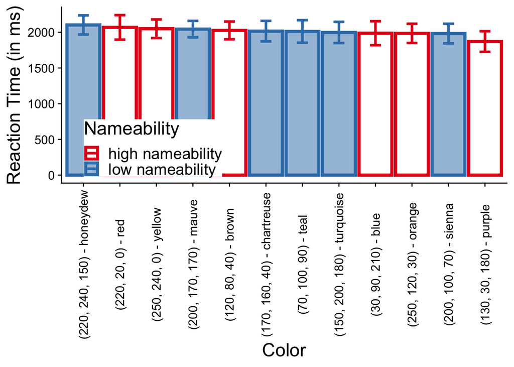

```r
kid_color_rt <- kid_color_rt %>%
  mutate(
    target_label = case_when(
      target=="red" ~ "(220, 20, 0) - red",
    target=="brown"~"(120, 80, 40) - brown",
    target=="blue"~"(30, 90, 210) - blue",
    target=="yellow"~"(250, 240, 0) - yellow",
    target=="purple"~"(130, 30, 180) - purple",
    target=="orange"~"(250, 120, 30) - orange",
    target=="pink"~"(200, 170, 170) - mauve",
    target=="mustard"~"(170, 160, 40) - chartreuse",
    target=="turquoise"~"(150, 200, 180) - turquoise",
    target=="neonyellow"~"(220, 240, 150) - honeydew",
    target=="darkgreenblue"~"(70, 100, 90) - teal",
    target=="lightred"~"(200, 100, 70) - sienna")
  )
ggplot(kid_color_rt, aes(reorder(target_label,-avg_rt,mean),avg_rt, color=condition))+
  geom_bar(aes(fill=condition,alpha=condition),stat="identity",size=1.5, position=position_dodge(.95))+
  geom_errorbar(aes(ymin=avg_rt-ci,ymax=avg_rt+ci), width=0.3,size=1.2, position=position_dodge(.95))+
  #coord_cartesian(ylim=c(500,700))+
  #ggtitle("Child Discriminability")+
  ylab("Reaction Time (in ms)")+
  xlab("Color")+
  scale_color_brewer(palette="Set1",name="Nameability")+
  scale_fill_brewer(palette="Set1",name="Nameability")+
  scale_alpha_manual(name="Nameability",values=c(0,0.5))+
  theme_cowplot()+
  theme(legend.position=c(0.05,0.2),legend.background=element_rect(fill="white")) +
  theme(axis.text.x  = element_text(angle=90, vjust=0.5),plot.title = element_text(hjust = 0.5))+
  theme(text=element_text(size=18))+
  theme(strip.text.x = element_text(size=16), plot.background = element_rect(fill="white",color="white"))
```

```r
ggsave(here::here("figures","kid_color_rt.png"),width=9, height=6,dpi=600)
```

#### Overall Results

Evaluating whether high nameability colors and low nameability colors differ in their average discriminability (RT-based)

```r
#overall average
kid_color_rt %>%
  group_by(condition) %>%
  summarize(
    N = n(),
    mean_rt = mean(avg_rt),
    sd = sd(avg_rt),
    ci = qt(0.975, N-1)*sd/sqrt(N),
    lower_ci = mean_rt-ci,
    upper_ci = mean_rt+ci
  ) %>%
  kable()
```

| condition | N | mean_rt | sd | ci | lower_ci | upper_ci |
| --- | --- | --- | --- | --- | --- | --- |
| high nameability | 6 | 1997.987 | 70.77964 | 74.27868 | 1923.709 | 2072.266 |
| low nameability | 6 | 2025.859 | 43.00997 | 45.13620 | 1980.723 | 2070.996 |

```r
# t-test
t.test(avg_rt ~ condition, data = kid_color_rt, paired = FALSE)
```

```
##
##  Welch Two Sample t-test
##
## data:  avg_rt by condition
## t = -0.82432, df = 8.2495, p-value = 0.4329
## alternative hypothesis: true difference in means between group high nameability and group low nameability is not equal to 0
## 95 percent confidence interval:
##  -105.43492   49.69051
## sample estimates:
## mean in group high nameability  mean in group low nameability
##                       1997.987                       2025.859
```

```r
#Bayes Factor
#evidence for the null hypothesis
1/ttestBF(kid_color_rt$avg_rt[kid_color_rt$condition=="high nameability"],kid_color_rt$avg_rt[kid_color_rt$condition=="low nameability"],paired=TRUE)
```

```
## Bayes factor analysis
## --------------
## [1] Null, mu=0 : 2.26596 ±0%
##
## Against denominator:
##   Alternative, r = 0.707106781186548, mu =/= 0
## ---
## Bayes factor type: BFoneSample, JZS
```

### Adults

```r
# participant reaction times for each color
adult_participant_color_rt <- an_data %>%
  filter(correct==1&condition!="practice"&rt<=2000&rt>=200) %>%
  group_by(subject_id,condition,target) %>%
  summarize(
    N=sum(!is.na(rt)),
    avg_rt=mean(rt,na.rm=T)
  )

#average reaction times for each color
adult_color_rt <- adult_participant_color_rt %>%
  ungroup() %>%
  select(-N) %>%
  summarySEwithin("avg_rt",withinvars=c("condition","target"),idvar="subject_id",na.rm=TRUE)

#join with color property data (from Zettersten & Lupyan, 2020)
adult_color_rt <- adult_color_rt %>%
  left_join(
    color_properties_zl,by=join_by(target==colorName)
  )
```

#### Plot

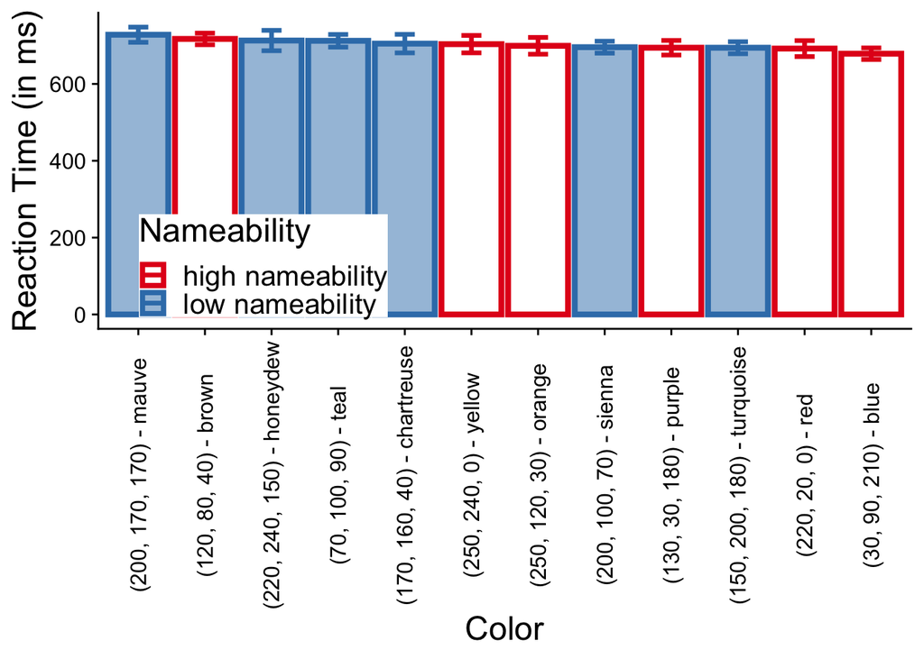

```r
adult_color_rt <- adult_color_rt %>%
  mutate(
    target_label = case_when(
      target=="red" ~ "(220, 20, 0) - red",
    target=="brown"~"(120, 80, 40) - brown",
    target=="blue"~"(30, 90, 210) - blue",
    target=="yellow"~"(250, 240, 0) - yellow",
    target=="purple"~"(130, 30, 180) - purple",
    target=="orange"~"(250, 120, 30) - orange",
    target=="pink"~"(200, 170, 170) - mauve",
    target=="mustard"~"(170, 160, 40) - chartreuse",
    target=="turquoise"~"(150, 200, 180) - turquoise",
    target=="neonyellow"~"(220, 240, 150) - honeydew",
    target=="darkgreenblue"~"(70, 100, 90) - teal",
    target=="lightred"~"(200, 100, 70) - sienna")
  )
ggplot(adult_color_rt, aes(reorder(target_label,-avg_rt,mean),avg_rt, color=condition))+
  geom_bar(aes(fill=condition,alpha=condition),stat="identity",size=1.5, position=position_dodge(.95))+
  geom_errorbar(aes(ymin=avg_rt-ci,ymax=avg_rt+ci), width=0.3,size=1.2, position=position_dodge(.95))+
  #coord_cartesian(ylim=c(500,700))+
  #ggtitle("Adult Discriminability")+
  ylab("Reaction Time (in ms)")+
  xlab("Color")+
  scale_color_brewer(palette="Set1",name="Nameability")+
  scale_fill_brewer(palette="Set1",name="Nameability")+
  scale_alpha_manual(name="Nameability",values=c(0,0.5))+
  theme_cowplot()+
  theme(legend.position=c(0.05,0.2),legend.background=element_rect(fill="white")) +
  theme(axis.text.x  = element_text(angle=90, vjust=0.5),plot.title = element_text(hjust = 0.5))+
  theme(text=element_text(size=18))+
  theme(strip.text.x = element_text(size=16), plot.background = element_rect(fill="white",color="white"))
```

```r
ggsave(here::here("figures","adult_color_rt.png"),width=9, height=6,dpi=600)
```

#### Overall Results

Evaluating whether high nameability colors and low nameability colors differ in their average discriminability (RT-based)

```r
#overall average
adult_color_rt %>%
  group_by(condition) %>%
  summarize(
    N = n(),
    mean_rt = mean(avg_rt),
    sd = sd(avg_rt),
    ci = qt(0.975, N-1)*sd/sqrt(N),
    lower_ci = mean_rt-ci,
    upper_ci = mean_rt+ci
  ) %>%
  kable()
```

| condition | N | mean_rt | sd | ci | lower_ci | upper_ci |
| --- | --- | --- | --- | --- | --- | --- |
| high nameability | 6 | 697.4225 | 12.83103 | 13.46535 | 683.9572 | 710.8878 |
| low nameability | 6 | 707.9727 | 12.61858 | 13.24238 | 694.7303 | 721.2151 |

```r
# t-test
t.test(avg_rt ~ condition, data = adult_color_rt, paired = FALSE)
```

```
##
##  Welch Two Sample t-test
##
## data:  avg_rt by condition
## t = -1.436, df = 9.9972, p-value = 0.1815
## alternative hypothesis: true difference in means between group high nameability and group low nameability is not equal to 0
## 95 percent confidence interval:
##  -26.920756   5.820423
## sample estimates:
## mean in group high nameability  mean in group low nameability
##                       697.4225                       707.9727
```

```r
#Bayes Factor
#evidence for the null hypothesis
1/ttestBF(adult_color_rt$avg_rt[adult_color_rt$condition=="high nameability"],adult_color_rt$avg_rt[adult_color_rt$condition=="low nameability"],paired=TRUE)
```

```
## Bayes factor analysis
## --------------
## [1] Null, mu=0 : 1.686861 ±0.01%
##
## Against denominator:
##   Alternative, r = 0.707106781186548, mu =/= 0
## ---
## Bayes factor type: BFoneSample, JZS
```

### Correlations

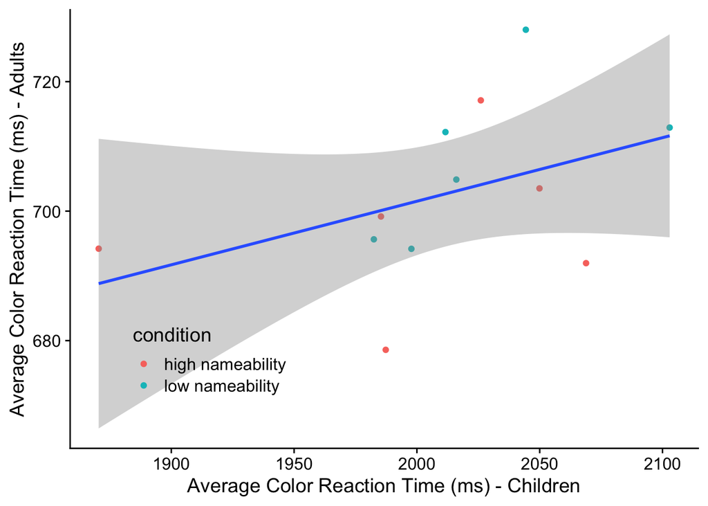

```r
adult_color_rt_to_join <- adult_color_rt %>%
  select(target,avg_rt) %>%
  rename(adult_avg_rt=avg_rt)
kid_color_rt <- kid_color_rt %>%
  left_join(adult_color_rt_to_join)

ggplot(kid_color_rt,aes(avg_rt,adult_avg_rt))+
  geom_point(aes(color=condition))+
  geom_smooth(method="lm")+
  xlab("Average Color Reaction Time (ms) - Children")+
  ylab("Average Color Reaction Time (ms) - Adults")+
  theme(legend.position=c(0.1,0.2))
```

```r
#Correlations
cor.test(
  kid_color_rt$avg_rt,
  kid_color_rt$adult_avg_rt,
)
```

```
##
##  Pearson's product-moment correlation
##
## data:  kid_color_rt$avg_rt and kid_color_rt$adult_avg_rt
## t = 1.4858, df = 10, p-value = 0.1682
## alternative hypothesis: true correlation is not equal to 0
## 95 percent confidence interval:
##  -0.1966373  0.8031451
## sample estimates:
##       cor
## 0.4252545
```

## Accuracy

### Children

```r
# participant accuracy for each color
kid_participant_color_acc <- kn_data %>%
  filter(condition!="practice") %>%
  group_by(subject_id,condition,target) %>%
  summarize(
    N=sum(!is.na(correct)),
    avg_accuracy=mean(correct,na.rm=T)
  )

#average accuracy for each color
kid_color_acc <- kid_participant_color_acc %>%
  ungroup() %>%
  select(-N) %>%
  summarySEwithin("avg_accuracy",withinvars=c("condition","target"),idvar="subject_id",na.rm=TRUE)
```

Evaluating whether high nameability colors and low nameability colors differ in their average accuracy

```r
#overall average
kid_color_acc %>%
  group_by(condition) %>%
  summarize(
    N = n(),
    mean_accuracy = mean(avg_accuracy),
    sd = sd(avg_accuracy),
    ci = qt(0.975, N-1)*sd/sqrt(N),
    lower_ci = mean_accuracy-ci,
    upper_ci = mean_accuracy+ci
  ) %>%
  kable()
```

| condition | N | mean_accuracy | sd | ci | lower_ci | upper_ci |
| --- | --- | --- | --- | --- | --- | --- |
| high nameability | 6 | 0.9622684 | 0.0169353 | 0.0177725 | 0.9444959 | 0.9800409 |
| low nameability | 6 | 0.9685219 | 0.0106186 | 0.0111435 | 0.9573784 | 0.9796655 |

```r
# t-test
t.test(avg_accuracy ~ condition, data = kid_color_acc, paired = FALSE)
```

```
##
##  Welch Two Sample t-test
##
## data:  avg_accuracy by condition
## t = -0.76632, df = 8.4051, p-value = 0.4645
## alternative hypothesis: true difference in means between group high nameability and group low nameability is not equal to 0
## 95 percent confidence interval:
##  -0.02491487  0.01240776
## sample estimates:
## mean in group high nameability  mean in group low nameability
##                      0.9622684                      0.9685219
```

```r
#Bayes Factor
#evidence for the null hypothesis
1/ttestBF(kid_color_acc$avg_accuracy[kid_color_acc$condition=="high nameability"],kid_color_acc$avg_accuracy[kid_color_acc$condition=="low nameability"],paired=TRUE)
```

```
## Bayes factor analysis
## --------------
## [1] Null, mu=0 : 1.809168 ±0.01%
##
## Against denominator:
##   Alternative, r = 0.707106781186548, mu =/= 0
## ---
## Bayes factor type: BFoneSample, JZS
```

### Adults

```r
# participant accuracy for each color
adult_participant_color_acc <- an_data %>%
  filter(condition!="practice") %>%
  group_by(subject_id,condition,target) %>%
  summarize(
    N=sum(!is.na(correct)),
    avg_accuracy=mean(correct,na.rm=T)
  )

#average accuracy for each color
adult_color_acc <- adult_participant_color_acc %>%
  ungroup() %>%
  select(-N) %>%
  summarySEwithin("avg_accuracy",withinvars=c("condition","target"),idvar="subject_id",na.rm=TRUE)
```

Evaluating whether high nameability colors and low nameability colors differ in their average accuracy

```r
#overall average
adult_color_acc %>%
  group_by(condition) %>%
  summarize(
    N = n(),
    mean_accuracy = mean(avg_accuracy),
    sd = sd(avg_accuracy),
    ci = qt(0.975, N-1)*sd/sqrt(N),
    lower_ci = mean_accuracy-ci,
    upper_ci = mean_accuracy+ci
  ) %>%
  kable()
```

| condition | N | mean_accuracy | sd | ci | lower_ci | upper_ci |
| --- | --- | --- | --- | --- | --- | --- |
| high nameability | 6 | 0.9972222 | 0.0038968 | 0.0040895 | 0.9931328 | 1.001312 |
| low nameability | 6 | 0.9966667 | 0.0051640 | 0.0054193 | 0.9912474 | 1.002086 |

```r
# t-test
t.test(avg_accuracy ~ condition, data = adult_color_acc, paired = FALSE)
```

```
##
##  Welch Two Sample t-test
##
## data:  avg_accuracy by condition
## t = 0.21035, df = 9.3001, p-value = 0.8379
## alternative hypothesis: true difference in means between group high nameability and group low nameability is not equal to 0
## 95 percent confidence interval:
##  -0.005389728  0.006500839
## sample estimates:
## mean in group high nameability  mean in group low nameability
##                      0.9972222                      0.9966667
```

```r
#Bayes Factor
#evidence for the null hypothesis
1/ttestBF(adult_color_acc$avg_accuracy[adult_color_acc$condition=="high nameability"],adult_color_acc$avg_accuracy[adult_color_acc$condition=="low nameability"],paired=TRUE)
```

```
## Bayes factor analysis
## --------------
## [1] Null, mu=0 : 2.630433 ±0%
##
## Against denominator:
##   Alternative, r = 0.707106781186548, mu =/= 0
## ---
## Bayes factor type: BFoneSample, JZS
```

# Color Pair Analysis

## Children

```r
# participant reaction times for each color pair
kid_participant_color_pair_rt <- kn_data %>%
  filter(correct==1&condition!="practice"&rt<=5000&rt>=200) %>%
  group_by(subject_id,condition,pair,colorPair) %>%
  summarize(
    N=sum(!is.na(rt)),
    avg_rt=mean(rt,na.rm=T)
  )

color_pairing <- kid_participant_color_pair_rt %>%
  ungroup() %>%
  select(pair,colorPair) %>%
  distinct()

#average reaction times for each color
kid_color_pair_rt <- kid_participant_color_pair_rt %>%
  ungroup() %>%
  select(-N) %>%
  summarySEwithin("avg_rt",withinvars=c("condition","pair"),idvar="subject_id",na.rm=TRUE) %>%
  left_join(color_pairing)

#join with color property data (from Zettersten & Lupyan, 2020)
kid_color_pair_rt <- kid_color_pair_rt %>%
  left_join(
    select(colorpair_discrim_rt_zl,colorPair,zl_average_rt,dE2000)
  ) %>%
  mutate(group="children")
```

### Plot

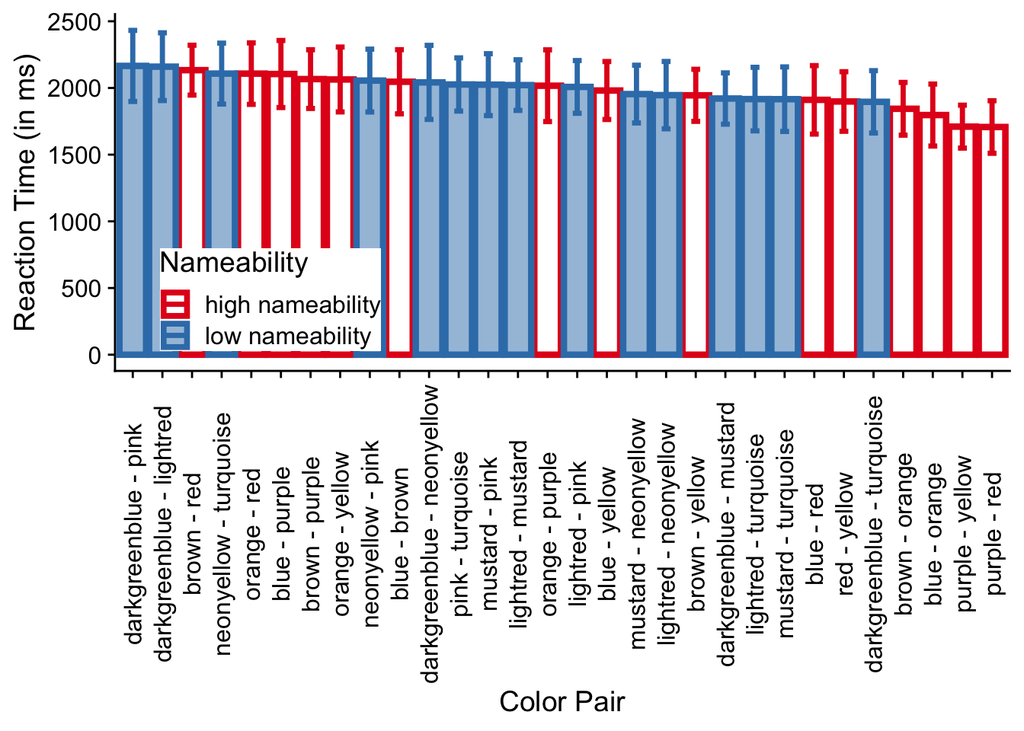

```r
ggplot(kid_color_pair_rt, aes(reorder(pair,-avg_rt,mean),avg_rt, color=condition))+
  geom_bar(aes(fill=condition,alpha=condition),stat="identity",size=1.5, position=position_dodge(.95))+
  geom_errorbar(aes(ymin=avg_rt-ci,ymax=avg_rt+ci), width=0.3,size=1.2, position=position_dodge(.95))+
  #coord_cartesian(ylim=c(500,700))+
  #ggtitle("Child Discriminability")+
  ylab("Reaction Time (in ms)")+
  xlab("Color Pair")+
  scale_color_brewer(palette="Set1",name="Nameability")+
  scale_fill_brewer(palette="Set1",name="Nameability")+
  scale_alpha_manual(name="Nameability",values=c(0,0.5))+
  theme(legend.position=c(0.05,0.2),legend.background=element_rect(fill="white")) +
  theme(axis.text.x  = element_text(angle=90, vjust=0.5),plot.title = element_text(hjust = 0.5))
```

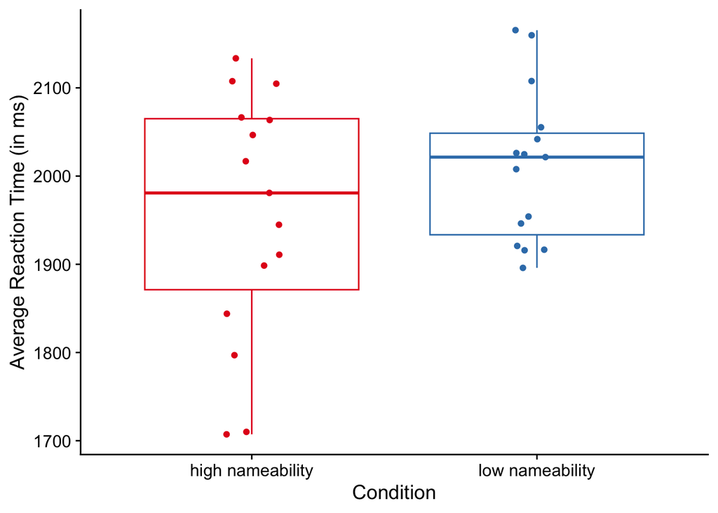

```r
ggplot(kid_color_pair_rt, aes(condition,avg_rt, color=condition))+
  geom_boxplot()+
  geom_jitter(width=0.1)+
  xlab("Condition")+
  theme(legend.position="none")+
  ylab("Average Reaction Time (in ms)")+
  scale_color_brewer(palette="Set1",name="Nameability")
```

### Overall Results

Evaluating whether high nameability colors and low nameability colors differ in their average discriminability (RT-based)

```r
#overall average
kid_color_pair_rt %>%
  group_by(condition) %>%
  summarize(
    N = n(),
    mean_rt = mean(avg_rt),
    sd = sd(avg_rt),
    ci = qt(0.975, N-1)*sd/sqrt(N),
    lower_ci = mean_rt-ci,
    upper_ci = mean_rt+ci
  ) %>%
  kable()
```

| condition | N | mean_rt | sd | ci | lower_ci | upper_ci |
| --- | --- | --- | --- | --- | --- | --- |
| high nameability | 15 | 1955.478 | 141.06121 | 78.11709 | 1877.361 | 2033.595 |
| low nameability | 15 | 2010.638 | 86.81263 | 48.07523 | 1962.563 | 2058.713 |

```r
# t-test
t.test(avg_rt ~ condition, data = kid_color_pair_rt, paired = FALSE)
```

```
##
##  Welch Two Sample t-test
##
## data:  avg_rt by condition
## t = -1.2898, df = 23.275, p-value = 0.2098
## alternative hypothesis: true difference in means between group high nameability and group low nameability is not equal to 0
## 95 percent confidence interval:
##  -143.57177   33.25162
## sample estimates:
## mean in group high nameability  mean in group low nameability
##                       1955.478                       2010.638
```

```r
#Bayes Factor
#evidence for the null hypothesis
1/ttestBF(kid_color_pair_rt$avg_rt[kid_color_pair_rt$condition=="high nameability"],kid_color_pair_rt$avg_rt[kid_color_pair_rt$condition=="low nameability"],paired=TRUE)
```

```
## Bayes factor analysis
## --------------
## [1] Null, mu=0 : 2.08854 ±0.02%
##
## Against denominator:
##   Alternative, r = 0.707106781186548, mu =/= 0
## ---
## Bayes factor type: BFoneSample, JZS
```

## Adults

```r
# participant reaction times for each color pair
adult_participant_color_pair_rt <- an_data %>%
  filter(correct==1&condition!="practice"&rt<=2000&rt>=200) %>%
  group_by(subject_id,condition,pair,colorPair) %>%
  summarize(
    N=sum(!is.na(rt)),
    avg_rt=mean(rt,na.rm=T)
  )

color_pairing <- adult_participant_color_pair_rt %>%
  ungroup() %>%
  select(pair,colorPair) %>%
  distinct()

#average reaction times for each color
adult_color_pair_rt <- adult_participant_color_pair_rt %>%
  ungroup() %>%
  select(-N) %>%
  summarySEwithin("avg_rt",withinvars=c("condition","pair"),idvar="subject_id",na.rm=TRUE) %>%
  left_join(color_pairing)

#join with color property data (from Zettersten & Lupyan, 2020)
adult_color_pair_rt <- adult_color_pair_rt %>%
  left_join(
    select(colorpair_discrim_rt_zl,colorPair,zl_average_rt,dE2000)
  )%>%
  mutate(group="adults")
```

### Plot

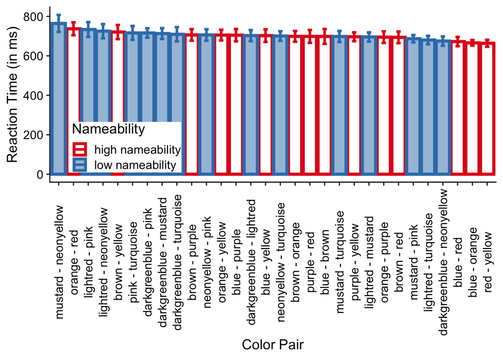

```r
ggplot(adult_color_pair_rt, aes(reorder(pair,-avg_rt,mean),avg_rt, color=condition))+
  geom_bar(aes(fill=condition,alpha=condition),stat="identity",size=1.5, position=position_dodge(.95))+
  geom_errorbar(aes(ymin=avg_rt-ci,ymax=avg_rt+ci), width=0.3,size=1.2, position=position_dodge(.95))+
  #coord_cartesian(ylim=c(500,700))+
  #ggtitle("Adult Discriminability")+
  ylab("Reaction Time (in ms)")+
  xlab("Color Pair")+
  scale_color_brewer(palette="Set1",name="Nameability")+
  scale_fill_brewer(palette="Set1",name="Nameability")+
  scale_alpha_manual(name="Nameability",values=c(0,0.5))+
  theme(legend.position=c(0.05,0.2),legend.background=element_rect(fill="white")) +
  theme(axis.text.x  = element_text(angle=90, vjust=0.5),plot.title = element_text(hjust = 0.5))
```

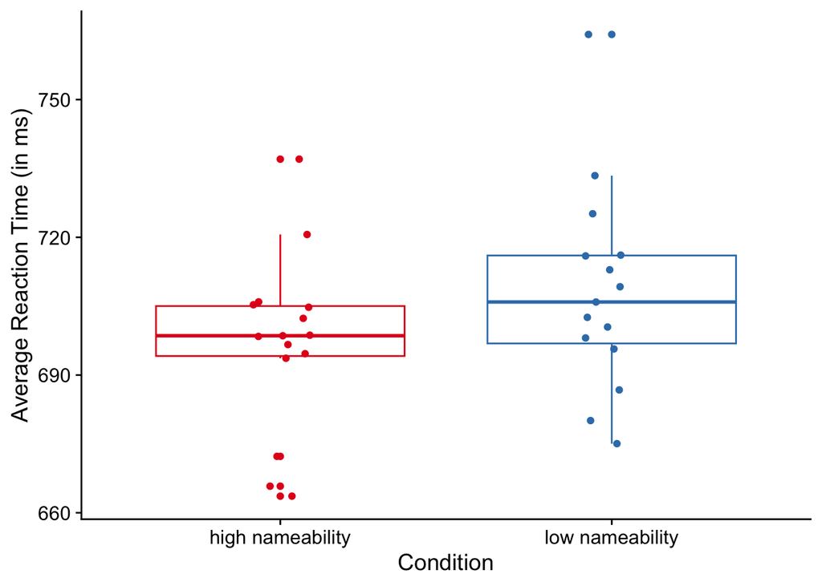

```r
ggplot(adult_color_pair_rt, aes(condition,avg_rt, color=condition))+
  geom_boxplot()+
  geom_jitter(width=0.1)+
  xlab("Condition")+
  theme(legend.position="none")+
  ylab("Average Reaction Time (in ms)")+
  scale_color_brewer(palette="Set1",name="Nameability")
```

### Overall Results

Evaluating whether high nameability colors and low nameability colors differ in their average discriminability (RT-based)

```r
#overall average
adult_color_pair_rt %>%
  group_by(condition) %>%
  summarize(
    N = n(),
    mean_rt = mean(avg_rt),
    sd = sd(avg_rt),
    ci = qt(0.975, N-1)*sd/sqrt(N),
    lower_ci = mean_rt-ci,
    upper_ci = mean_rt+ci
  ) %>%
  kable()
```

| condition | N | mean_rt | sd | ci | lower_ci | upper_ci |
| --- | --- | --- | --- | --- | --- | --- |
| high nameability | 15 | 697.2153 | 19.12245 | 10.58966 | 686.6257 | 707.805 |
| low nameability | 15 | 708.1060 | 22.21639 | 12.30302 | 695.8030 | 720.409 |

```r
# t-test
t.test(avg_rt ~ condition, data = adult_color_pair_rt, paired = FALSE)
```

```
##
##  Welch Two Sample t-test
##
## data:  avg_rt by condition
## t = -1.4389, df = 27.393, p-value = 0.1615
## alternative hypothesis: true difference in means between group high nameability and group low nameability is not equal to 0
## 95 percent confidence interval:
##  -26.40955   4.62822
## sample estimates:
## mean in group high nameability  mean in group low nameability
##                       697.2153                       708.1060
```

```r
#Bayes Factor
#evidence for the null hypothesis
1/ttestBF(adult_color_pair_rt$avg_rt[adult_color_pair_rt$condition=="high nameability"],adult_color_pair_rt$avg_rt[adult_color_pair_rt$condition=="low nameability"],paired=TRUE)
```

```
## Bayes factor analysis
## --------------
## [1] Null, mu=0 : 2.062726 ±0.02%
##
## Against denominator:
##   Alternative, r = 0.707106781186548, mu =/= 0
## ---
## Bayes factor type: BFoneSample, JZS
```

## Correlations

### Kids vs. Adults

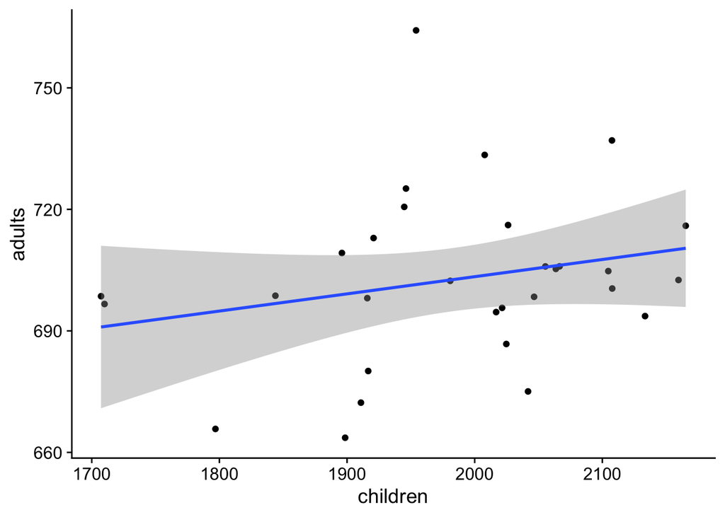

```r
color_pair_rt <- kid_color_pair_rt %>%
  bind_rows(adult_color_pair_rt)

color_pair_rt_wide <- color_pair_rt %>%
  select(-N,-se,-sd,-ci,-avg_rt_norm,-zl_average_rt,-dE2000,-colorPair) %>%
  pivot_wider(
    names_from="group",
    values_from="avg_rt"
  )

ggplot(color_pair_rt_wide, aes(children, adults))+
  geom_point()+
  geom_smooth(method="lm")
```

```r
cor.test(
  color_pair_rt_wide$children,
  color_pair_rt_wide$adults,
)
```

```
##
##  Pearson's product-moment correlation
##
## data:  color_pair_rt_wide$children and color_pair_rt_wide$adults
## t = 1.2974, df = 28, p-value = 0.2051
## alternative hypothesis: true correlation is not equal to 0
## 95 percent confidence interval:
##  -0.1335968  0.5511213
## sample estimates:
##      cor
## 0.238134
```

# Main Linear Mixed-effects Model

## Children

### Reaction Time

We fit a trial-by-trial linear mixed effects model prediction reaction time from condition, including a by-participant random intercept and random slope for condition and a by-color-pair random intercept.

```r
kn_data <- kn_data %>%
  mutate(condition_c=ifelse(condition=="high nameability",0.5,-0.5))
m <- lmer(rt ~ condition_c+(1+condition_c|subject_id)+(1|pair),data=filter(kn_data,rt<=5000&correct==1&condition!="practice"))
summary(m)
```

```
## Linear mixed model fit by REML. t-tests use Satterthwaite's method [
## lmerModLmerTest]
## Formula: rt ~ condition_c + (1 + condition_c | subject_id) + (1 | pair)
##    Data: filter(kn_data, rt <= 5000 & correct == 1 & condition != "practice")
##
## REML criterion at convergence: 33074.9
##
## Scaled residuals:
##     Min      1Q  Median      3Q     Max
## -2.7784 -0.6871 -0.2523  0.4923  3.6202
##
## Random effects:
##  Groups     Name        Variance Std.Dev. Corr
##  subject_id (Intercept) 205517.0 453.34
##             condition_c    535.5  23.14   1.00
##  pair       (Intercept)      0.0   0.00
##  Residual               749434.7 865.70
## Number of obs: 2016, groups:  subject_id, 40; pair, 30
##
## Fixed effects:
##             Estimate Std. Error      df t value Pr(>|t|)
## (Intercept)  2017.35      74.99   36.87  26.903   <2e-16 ***
## condition_c   -57.23      38.77 1011.59  -1.476     0.14
## ---
## Signif. codes:  0 '***' 0.001 '**' 0.01 '*' 0.05 '.' 0.1 ' ' 1
##
## Correlation of Fixed Effects:
##             (Intr)
## condition_c 0.086
## optimizer (nloptwrap) convergence code: 0 (OK)
## boundary (singular) fit: see help('isSingular')
```

Reaction times decline with age, but there is no interaction with condition

```r
m <- lmer(rt ~ condition_c*age_months+(1+condition_c|subject_id)+(1|pair),data=filter(kn_data,rt<=5000&correct==1&condition!="practice"))
summary(m)
```

```
## Linear mixed model fit by REML. t-tests use Satterthwaite's method [
## lmerModLmerTest]
## Formula: rt ~ condition_c * age_months + (1 + condition_c | subject_id) +
##     (1 | pair)
##    Data: filter(kn_data, rt <= 5000 & correct == 1 & condition != "practice")
##
## REML criterion at convergence: 33057.8
##
## Scaled residuals:
##     Min      1Q  Median      3Q     Max
## -2.7907 -0.6853 -0.2493  0.4874  3.6249
##
## Random effects:
##  Groups     Name        Variance Std.Dev. Corr
##  subject_id (Intercept) 187864.9 433.4
##             condition_c    449.6  21.2    1.00
##  pair       (Intercept)      0.0   0.0
##  Residual               749544.8 865.8
## Number of obs: 2016, groups:  subject_id, 40; pair, 30
##
## Fixed effects:
##                        Estimate Std. Error       df t value Pr(>|t|)
## (Intercept)            3441.009    640.205   38.044   5.375 4.08e-06 ***
## condition_c              37.359    356.604 1250.831   0.105   0.9166
## age_months              -25.223     11.261   37.786  -2.240   0.0311 *
## condition_c:age_months   -1.680      6.228 1223.142  -0.270   0.7874
## ---
## Signif. codes:  0 '***' 0.001 '**' 0.01 '*' 0.05 '.' 0.1 ' ' 1
##
## Correlation of Fixed Effects:
##             (Intr) cndtn_ ag_mnt
## condition_c  0.067
## age_months  -0.994 -0.067
## cndtn_c:g_m -0.067 -0.994  0.068
## optimizer (nloptwrap) convergence code: 0 (OK)
## boundary (singular) fit: see help('isSingular')
```

### Accuracy

```r
m <- glmer(correct ~ condition_c+(1+condition_c|subject_id)+(1|pair),data=filter(kn_data,rt<=5000&condition!="practice"),family="binomial")
summary(m)
```

```
## Generalized linear mixed model fit by maximum likelihood (Laplace
##   Approximation) [glmerMod]
##  Family: binomial  ( logit )
## Formula: correct ~ condition_c + (1 + condition_c | subject_id) + (1 |
##     pair)
##    Data: filter(kn_data, rt <= 5000 & condition != "practice")
##
##      AIC      BIC   logLik deviance df.resid
##    745.6    779.5   -366.8    733.6     2102
##
## Scaled residuals:
##     Min      1Q  Median      3Q     Max
## -6.2162  0.1443  0.1684  0.2226  0.4932
##
## Random effects:
##  Groups     Name        Variance Std.Dev. Corr
##  subject_id (Intercept) 0.63815  0.7988
##             condition_c 0.41025  0.6405   0.39
##  pair       (Intercept) 0.08115  0.2849
## Number of obs: 2108, groups:  subject_id, 40; pair, 30
##
## Fixed effects:
##             Estimate Std. Error z value Pr(>|z|)
## (Intercept)  3.46654    0.21950  15.793   <2e-16 ***
## condition_c -0.00809    0.35555  -0.023    0.982
## ---
## Signif. codes:  0 '***' 0.001 '**' 0.01 '*' 0.05 '.' 0.1 ' ' 1
##
## Correlation of Fixed Effects:
##             (Intr)
## condition_c 0.075
```

No interaction between condition and age

```r
m <- glmer(correct ~ condition_c*age_months+(1+condition_c|subject_id)+(1|pair),data=filter(kn_data,rt<=5000&condition!="practice"),family="binomial",glmerControl(optimizer="bobyqa"))
summary(m)
```

```
## Generalized linear mixed model fit by maximum likelihood (Laplace
##   Approximation) [glmerMod]
##  Family: binomial  ( logit )
## Formula: correct ~ condition_c * age_months + (1 + condition_c | subject_id) +
##     (1 | pair)
##    Data: filter(kn_data, rt <= 5000 & condition != "practice")
## Control: glmerControl(optimizer = "bobyqa")
##
##      AIC      BIC   logLik deviance df.resid
##    747.9    793.1   -366.0    731.9     2100
##
## Scaled residuals:
##     Min      1Q  Median      3Q     Max
## -6.7754  0.1408  0.1704  0.2208  0.4996
##
## Random effects:
##  Groups     Name        Variance Std.Dev. Corr
##  subject_id (Intercept) 0.60217  0.7760
##             condition_c 0.44166  0.6646   0.39
##  pair       (Intercept) 0.08392  0.2897
## Number of obs: 2108, groups:  subject_id, 40; pair, 30
##
## Fixed effects:
##                         Estimate Std. Error z value Pr(>|z|)
## (Intercept)             1.446082   1.572422   0.920    0.358
## condition_c             0.222853   2.320342   0.096    0.923
## age_months              0.035772   0.027936   1.281    0.200
## condition_c:age_months -0.004072   0.041511  -0.098    0.922
##
## Correlation of Fixed Effects:
##             (Intr) cndtn_ ag_mnt
## condition_c  0.056
## age_months  -0.990 -0.051
## cndtn_c:g_m -0.052 -0.988  0.050
```

## Adults

### Reaction Time

We fit a trial-by-trial linear mixed effects model prediction reaction time from condition, including a by-participant random intercept and random slope for condition and a by-color-pair random intercept.

```r
an_data <- an_data %>%
  mutate(condition_c=ifelse(condition=="high nameability",0.5,-0.5))
m <- lmer(rt ~ condition_c+(1+condition_c|subject_id)+(1|pair),data=filter(an_data,rt<=2000&correct==1&condition!="practice"))
summary(m)
```

```
## Linear mixed model fit by REML. t-tests use Satterthwaite's method [
## lmerModLmerTest]
## Formula: rt ~ condition_c + (1 + condition_c | subject_id) + (1 | pair)
##    Data: filter(an_data, rt <= 2000 & correct == 1 & condition != "practice")
##
## REML criterion at convergence: 38714.3
##
## Scaled residuals:
##     Min      1Q  Median      3Q     Max
## -2.5430 -0.4753 -0.1596  0.1982  8.2731
##
## Random effects:
##  Groups     Name        Variance Std.Dev. Corr
##  subject_id (Intercept) 14002.26 118.331
##             condition_c    52.53   7.248  -1.00
##  pair       (Intercept)   202.73  14.238
##  Residual               22720.14 150.732
## Number of obs: 2994, groups:  subject_id, 50; pair, 30
##
## Fixed effects:
##             Estimate Std. Error      df t value Pr(>|t|)
## (Intercept)  702.720     17.158  51.113  40.956   <2e-16 ***
## condition_c  -10.822      7.644  28.638  -1.416    0.168
## ---
## Signif. codes:  0 '***' 0.001 '**' 0.01 '*' 0.05 '.' 0.1 ' ' 1
##
## Correlation of Fixed Effects:
##             (Intr)
## condition_c -0.131
## optimizer (nloptwrap) convergence code: 0 (OK)
## boundary (singular) fit: see help('isSingular')
```

### Accuracy

```r
m <- glmer(correct ~ condition_c+(1+condition_c|subject_id)+(1|pair),data=filter(kn_data,rt<=2000&condition!="practice"),family="binomial",glmerControl(optimizer="bobyqa"))
summary(m)
```

```
## Generalized linear mixed model fit by maximum likelihood (Laplace
##   Approximation) [glmerMod]
##  Family: binomial  ( logit )
## Formula: correct ~ condition_c + (1 + condition_c | subject_id) + (1 |
##     pair)
##    Data: filter(kn_data, rt <= 2000 & condition != "practice")
## Control: glmerControl(optimizer = "bobyqa")
##
##      AIC      BIC   logLik deviance df.resid
##    581.4    612.6   -284.7    569.4     1332
##
## Scaled residuals:
##     Min      1Q  Median      3Q     Max
## -5.4457  0.1836  0.2062  0.2512  0.4147
##
## Random effects:
##  Groups     Name        Variance Std.Dev. Corr
##  subject_id (Intercept) 0.412434 0.64221
##             condition_c 0.136987 0.37012  -0.41
##  pair       (Intercept) 0.006471 0.08044
## Number of obs: 1338, groups:  subject_id, 40; pair, 30
##
## Fixed effects:
##             Estimate Std. Error z value Pr(>|z|)
## (Intercept)  3.03797    0.20974   14.48   <2e-16 ***
## condition_c  0.06529    0.34277    0.19    0.849
## ---
## Signif. codes:  0 '***' 0.001 '**' 0.01 '*' 0.05 '.' 0.1 ' ' 1
##
## Correlation of Fixed Effects:
##             (Intr)
## condition_c 0.005
```

## Child - Adult Interaction

We also found no significant interaction between age group and condition in a linear mixed-effects model.

```r
overall_data <- kn_data %>%
  select(-home_income,-parental_education,-family_history_color_blindness,-color_blindness_dx) %>%
  bind_rows(select(an_data,-home_income,-parental_education,-family_history_color_blindness,-color_blindness_dx)) %>%
  mutate(age_group_c=ifelse(age_group=="children",-0.5,0.5))
m <- lmer(rt~ condition_c*age_group_c+(1+condition_c|subject_id)+(1|pair),data=filter(overall_data,rt<=5000&correct==1&condition!="practice"))
summary(m)
```

```
## Linear mixed model fit by REML. t-tests use Satterthwaite's method [
## lmerModLmerTest]
## Formula: rt ~ condition_c * age_group_c + (1 + condition_c | subject_id) +
##     (1 | pair)
##    Data: filter(overall_data, rt <= 5000 & correct == 1 & condition !=
##     "practice")
##
## REML criterion at convergence: 78019.9
##
## Scaled residuals:
##     Min      1Q  Median      3Q     Max
## -4.2645 -0.2661 -0.0709  0.1011  5.5680
##
## Random effects:
##  Groups     Name        Variance Std.Dev. Corr
##  subject_id (Intercept)  98948.5 314.56
##             condition_c    152.8  12.36   1.00
##  pair       (Intercept)    114.1  10.68
##  Residual               318823.5 564.64
## Number of obs: 5016, groups:  subject_id, 90; pair, 30
##
## Fixed effects:
##                         Estimate Std. Error       df t value Pr(>|t|)
## (Intercept)              1362.67      34.58    82.36  39.409   <2e-16 ***
## condition_c               -33.42      16.78    30.38  -1.991   0.0555 .
## age_group_c             -1312.36      69.04    82.39 -19.007   <2e-16 ***
## condition_c:age_group_c    49.41      32.65  2707.68   1.513   0.1303
## ---
## Signif. codes:  0 '***' 0.001 '**' 0.01 '*' 0.05 '.' 0.1 ' ' 1
##
## Correlation of Fixed Effects:
##             (Intr) cndtn_ ag_gr_
## condition_c  0.073
## age_group_c -0.125 -0.006
## cndtn_c:g__ -0.006 -0.191  0.075
## optimizer (nloptwrap) convergence code: 0 (OK)
## boundary (singular) fit: see help('isSingular')
```

# Relation with Zettersten & Lupyan (2020) norming data

## ZL discriminability - Single Color

### Children & ZL discriminability

#### Correlation Plot

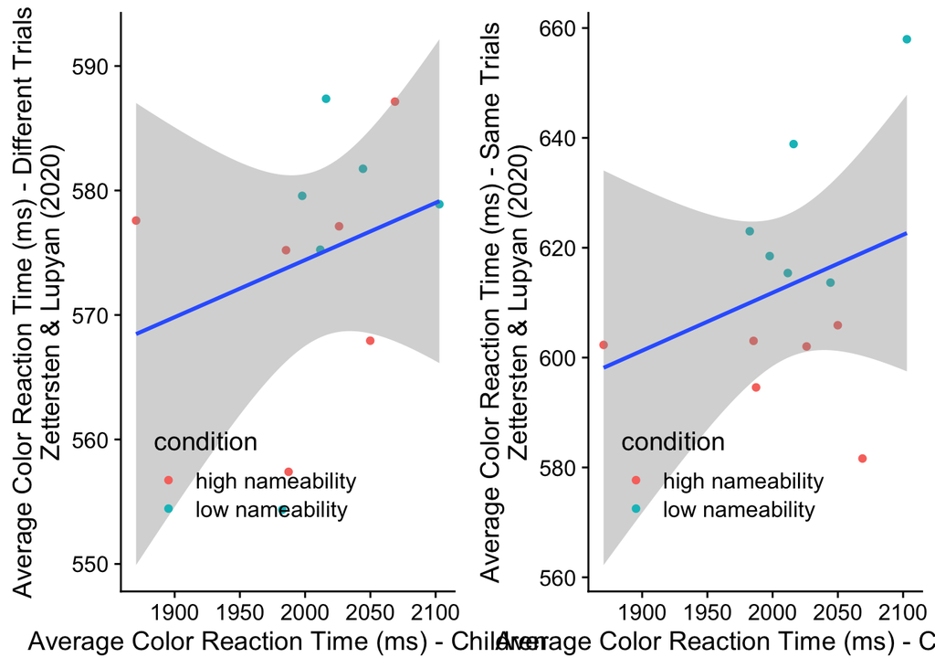

```r
p1 <- ggplot(kid_color_rt,aes(avg_rt,rt_different))+
  geom_point(aes(color=condition))+
  geom_smooth(method="lm")+
  xlab("Average Color Reaction Time (ms) - Children")+
  ylab("Average Color Reaction Time (ms) - Different Trials\nZettersten & Lupyan (2020)")+
  theme(legend.position=c(0.1,0.2))

p2 <- ggplot(kid_color_rt,aes(avg_rt,rt_same))+
  geom_point(aes(color=condition))+
  geom_smooth(method="lm")+
  xlab("Average Color Reaction Time (ms) - Children")+
  ylab("Average Color Reaction Time (ms) - Same Trials\nZettersten & Lupyan (2020)")+
  theme(legend.position=c(0.1,0.2))

plot_grid(p1,p2)
```

#### Correlation - Different Trials

```r
#Correlations
cor.test(
  kid_color_rt$avg_rt,
  kid_color_rt$rt_different,
)
```

```
##
##  Pearson's product-moment correlation
##
## data:  kid_color_rt$avg_rt and kid_color_rt$rt_different
## t = 0.83735, df = 10, p-value = 0.422
## alternative hypothesis: true correlation is not equal to 0
## 95 percent confidence interval:
##  -0.3726785  0.7235771
## sample estimates:
##       cor
## 0.2559703
```

#### Correlation - Same Trials

```r
cor.test(
  kid_color_rt$avg_rt,
  kid_color_rt$rt_same,
)
```

```
##
##  Pearson's product-moment correlation
##
## data:  kid_color_rt$avg_rt and kid_color_rt$rt_same
## t = 0.99379, df = 10, p-value = 0.3438
## alternative hypothesis: true correlation is not equal to 0
## 95 percent confidence interval:
##  -0.3310550  0.7454477
## sample estimates:
##       cor
## 0.2998081
```

### Adults & ZL discriminability

#### Correlation Plot

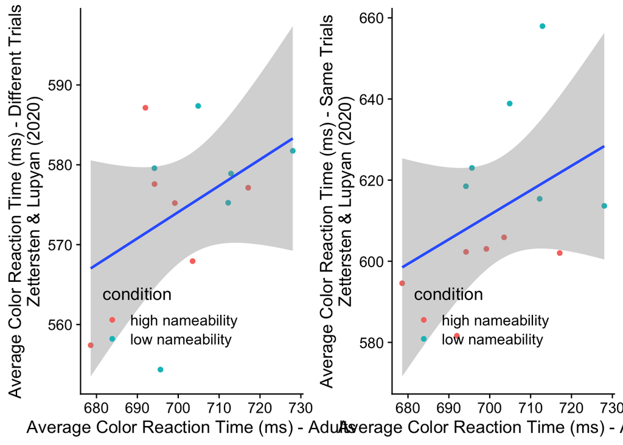

```r
p1 <- ggplot(adult_color_rt,aes(avg_rt,rt_different))+
  geom_point(aes(color=condition))+
  geom_smooth(method="lm")+
  xlab("Average Color Reaction Time (ms) - Adults")+
  ylab("Average Color Reaction Time (ms) - Different Trials\nZettersten & Lupyan (2020)")+
  theme(legend.position=c(0.1,0.2))

p2 <- ggplot(adult_color_rt,aes(avg_rt,rt_same))+
  geom_point(aes(color=condition))+
  geom_smooth(method="lm")+
  xlab("Average Color Reaction Time (ms) - Adults")+
  ylab("Average Color Reaction Time (ms) - Same Trials\nZettersten & Lupyan (2020)")+
  theme(legend.position=c(0.1,0.2))

plot_grid(p1,p2)
```

#### Correlation - Different Trials

```r
#Correlations
cor.test(
  adult_color_rt$avg_rt,
  adult_color_rt$rt_different,
)
```

```
##
##  Pearson's product-moment correlation
##
## data:  adult_color_rt$avg_rt and adult_color_rt$rt_different
## t = 1.4791, df = 10, p-value = 0.1699
## alternative hypothesis: true correlation is not equal to 0
## 95 percent confidence interval:
##  -0.1984921  0.8024590
## sample estimates:
##       cor
## 0.4236721
```

#### Correlation - Same Trials

```r
cor.test(
  adult_color_rt$avg_rt,
  adult_color_rt$rt_same,
)
```

```
##
##  Pearson's product-moment correlation
##
## data:  adult_color_rt$avg_rt and adult_color_rt$rt_same
## t = 1.3664, df = 10, p-value = 0.2018
## alternative hypothesis: true correlation is not equal to 0
## 95 percent confidence interval:
##  -0.2294993  0.7905820
## sample estimates:
##       cor
## 0.3966443
```

## ZL discriminability - Color Pairs

### Children & ZL discriminability

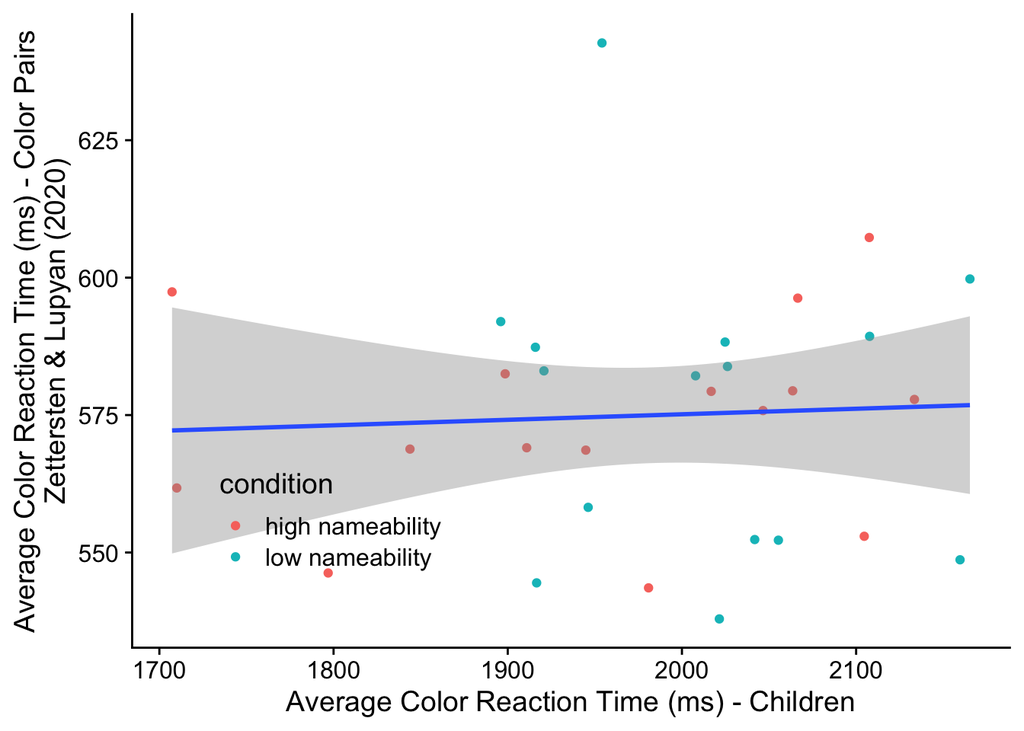

```r
ggplot(kid_color_pair_rt,aes(avg_rt,zl_average_rt))+
  geom_point(aes(color=condition))+
  geom_smooth(method="lm")+
  xlab("Average Color Reaction Time (ms) - Children")+
  ylab("Average Color Reaction Time (ms) - Color Pairs\nZettersten & Lupyan (2020)")+
  theme(legend.position=c(0.1,0.2))
```

```r
#Correlations
cor.test(
  kid_color_pair_rt$avg_rt,
  kid_color_pair_rt$zl_average_rt,
)
```

```
##
##  Pearson's product-moment correlation
##
## data:  kid_color_pair_rt$avg_rt and kid_color_pair_rt$zl_average_rt
## t = 0.27549, df = 28, p-value = 0.785
## alternative hypothesis: true correlation is not equal to 0
## 95 percent confidence interval:
##  -0.3141613  0.4046816
## sample estimates:
##        cor
## 0.05199258
```

### Adults & ZL discriminability

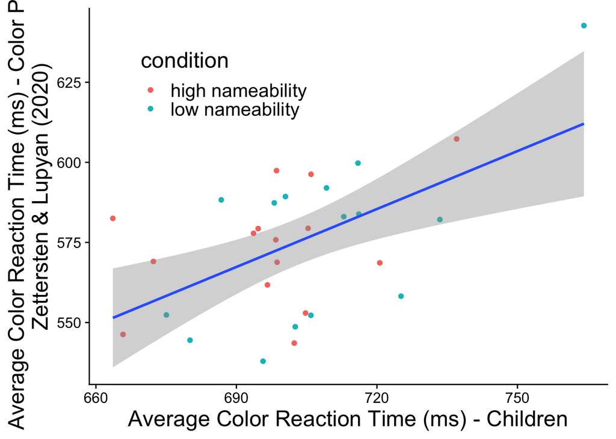

```r
ggplot(adult_color_pair_rt,aes(avg_rt,zl_average_rt))+
  geom_point(aes(color=condition))+
  geom_smooth(method="lm")+
  xlab("Average Color Reaction Time (ms) - Children")+
  ylab("Average Color Reaction Time (ms) - Color Pairs\nZettersten & Lupyan (2020)")+
  theme(legend.position=c(0.1,0.8))+
  theme(text=element_text(size=18))+
  theme(strip.text.x = element_text(size=16), plot.background = element_rect(fill="white",color="white"))
```

```r
ggsave(here::here("figures","adult_zl2020.png"),width=9, height=6,dpi=600)
```

```r
#Correlations
cor.test(
  adult_color_pair_rt$avg_rt,
  adult_color_pair_rt$zl_average_rt,
)
```

```
##
##  Pearson's product-moment correlation
##
## data:  adult_color_pair_rt$avg_rt and adult_color_pair_rt$zl_average_rt
## t = 3.5351, df = 28, p-value = 0.001439
## alternative hypothesis: true correlation is not equal to 0
## 95 percent confidence interval:
##  0.2440871 0.7630627
## sample estimates:
##       cor
## 0.5555067
```

## deltaE 2000

### Children & deltaE2000

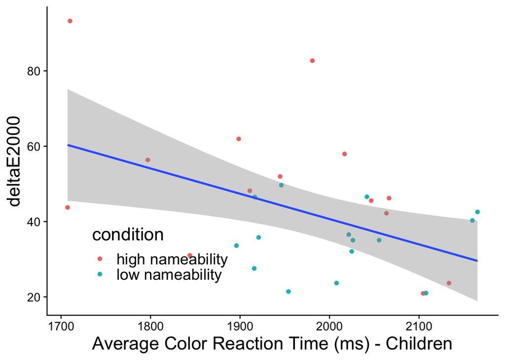

```r
ggplot(kid_color_pair_rt,aes(avg_rt,dE2000))+
  geom_point(aes(color=condition))+
  geom_smooth(method="lm")+
  xlab("Average Color Reaction Time (ms) - Children")+
  ylab("deltaE2000")+
  theme(legend.position=c(0.1,0.2))+
  theme(text=element_text(size=18))+
  theme(strip.text.x = element_text(size=16), plot.background = element_rect(fill="white",color="white"))
```

```r
ggsave(here::here("figures","kid_dE2000.png"),width=9, height=6,dpi=600)
```

Children’s reaction times correlated with deltaE2000 values.

```r
#Correlations
cor.test(
  kid_color_pair_rt$avg_rt,
  kid_color_pair_rt$dE2000,
)
```

```
##
##  Pearson's product-moment correlation
##
## data:  kid_color_pair_rt$avg_rt and kid_color_pair_rt$dE2000
## t = -2.7797, df = 28, p-value = 0.009614
## alternative hypothesis: true correlation is not equal to 0
## 95 percent confidence interval:
##  -0.7068843 -0.1258672
## sample estimates:
##        cor
## -0.4650483
```

### Adults & deltaE2000

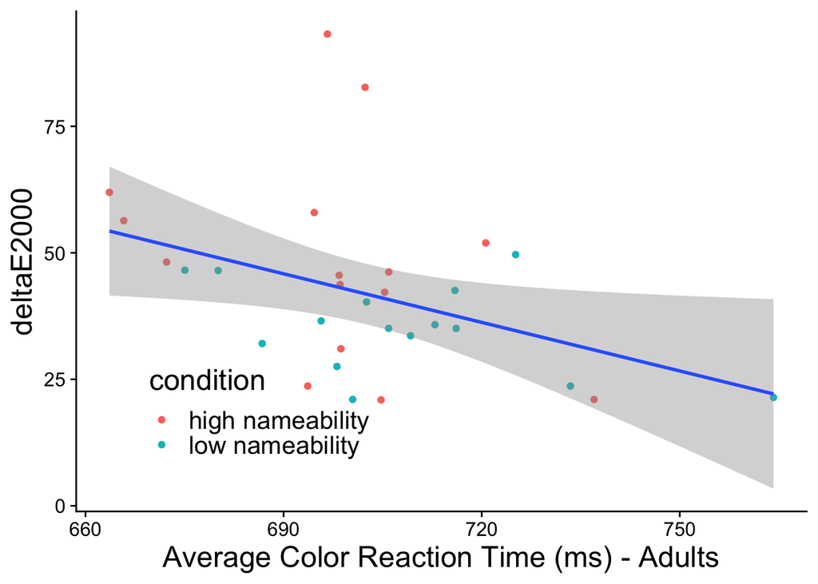

```r
ggplot(adult_color_pair_rt,aes(avg_rt,dE2000))+
  geom_point(aes(color=condition))+
  geom_smooth(method="lm")+
  xlab("Average Color Reaction Time (ms) - Adults")+
  ylab("deltaE2000")+
  theme(legend.position=c(0.1,0.2))+
  theme(text=element_text(size=18))+
  theme(strip.text.x = element_text(size=16), plot.background = element_rect(fill="white",color="white"))
```

```r
ggsave(here::here("figures","adult_dE2000.png"),width=9, height=6,dpi=600)
```

Adults’ reaction times correlated with deltaE2000 values.

```r
#Correlations
cor.test(
  adult_color_pair_rt$avg_rt,
  adult_color_pair_rt$dE2000,
)
```

```
##
##  Pearson's product-moment correlation
##
## data:  adult_color_pair_rt$avg_rt and adult_color_pair_rt$dE2000
## t = -2.2736, df = 28, p-value = 0.03086
## alternative hypothesis: true correlation is not equal to 0
## 95 percent confidence interval:
##  -0.66102293 -0.04021603
## sample estimates:
##        cor
## -0.3947657
```

### ZL discriminability (adults) & deltaE2000

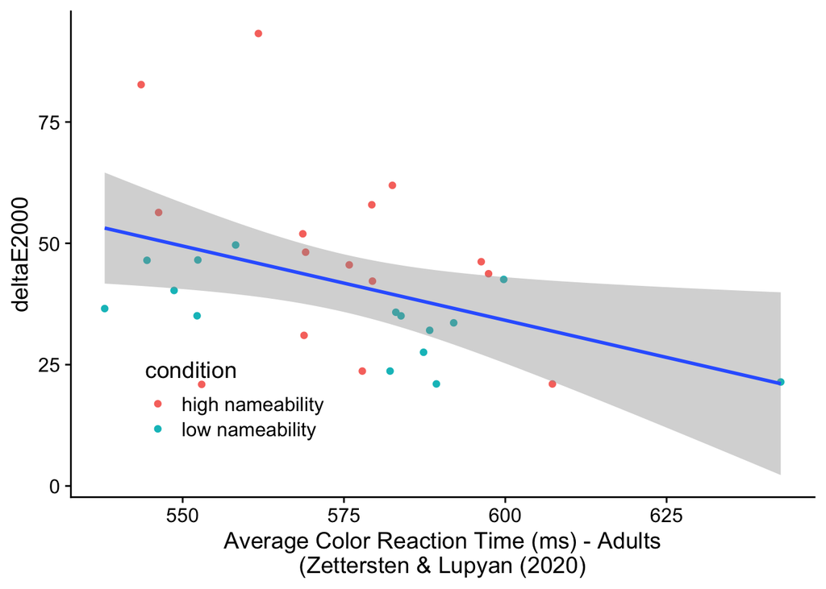

```r
ggplot(adult_color_pair_rt,aes(zl_average_rt,dE2000))+
  geom_point(aes(color=condition))+
  geom_smooth(method="lm")+
  xlab("Average Color Reaction Time (ms) - Adults\n(Zettersten & Lupyan (2020)")+
  ylab("deltaE2000")+
  theme(legend.position=c(0.1,0.2))
```

Adults’ reaction times correlated with deltaE2000 values.

```r
#Correlations
cor.test(
  adult_color_pair_rt$zl_average_rt,
  adult_color_pair_rt$dE2000,
)
```

```
##
##  Pearson's product-moment correlation
##
## data:  adult_color_pair_rt$zl_average_rt and adult_color_pair_rt$dE2000
## t = -2.3761, df = 28, p-value = 0.02457
## alternative hypothesis: true correlation is not equal to 0
## 95 percent confidence interval:
##  -0.67089704 -0.05791726
## sample estimates:
##       cor
## -0.409639
```